# Raport PD1

Jadwiga Słowik

16 marca 2017

# Zadanie 1

## Dyskusja

Pierwsze zadanie polegało na obliczeniu współczynnika korelacji Kendalla przy założeniu, że dane wektory będą miały unikalne wartości.

Główną częścią zadania było obliczenie liczby par zgodnych. Istnieją co najmniej dwa sposoby rozwiązania tej części zadania.

### Rozwiązanie 1

Algorytm jest następujący. Dla każdego z wektorów $x$ i $y$ jest obliczana pośrednio lista, która na $i$-tej pozycji zawiera indeksy elementów w analizowanym wektorze. Elementy znajdujące się pod tymi indeksami są większe od $i$-tej wartości w danym wektorze.

```
lapply(x, function(k) which(x > k))
lapply(y, function(k) which(y > k))
```

Wobec tego, po wykonaniu tych operacji otrzymujemy dwie listy (wektorów) indeksów.

Zauważmy, że aby znaleźć wszystkie pary $(x_i,\, y_j)$ takie, że $i < j$ oraz $x_i < x_j$ lub $x_i > x_j$ wystarczy znaleźć wszystkie pary $(x_i,\, x_j)$, gdzie $i \neq j,\, x_i < x_j$

Następnie, dla każdej pozycji obliczamy część wspólną indeksów zawartych w pierwszym i drugim wektorze.

```
mapply(intersect, a, b)
```

Ostatecznie, obliczamy, ile łącznie ,,indeksów’’ znalazło się na wynikowej (po obliczeniu przecięcia) liście.

### Rozwiązanie 2

Drugie rozwiązanie używa funkcji `outer`. Mianowicie, na początku dla każdego wektora (`x` i `y`) obliczana jest macierz rozmiaru `n` $\times$ `n` ($n = length(x) = length(y)$), w której komórka o adresie $(i,\, j)$ przyjmuje wartość `TRUE` wtedy i tylko wtedy, gdy $x_i < x_j$ (dla drugiego wektora: $y_i < y_j$), w przeciwnym wypadku – `FALSE`.

Następnie, obliczana jest logiczna koniunkcja odpowiadających sobie elementów tychże macierzy. Otrzymana w ten sposób macierz reprezentuje wybór par indeksów, które spełniają warunki danego zadania.

Jako że poszukujemy jedynie liczby par, to zliczamy, ile w wynikowej macierzy występuje komórek, które mają wartość `TRUE`.

### Krótkie porównanie

Jednakże funkcje typowo zwektoryzowane zwykle działają nieco szybciej niż funkcje typu `*apply`.

## Testy

### Test 1

```r
x <- c(1,2,3,4,5)
y <- c(1,2,3,4,5)
kendall(x, y)
```

```
## [1] 1
```

```r
cor(x, y, method="kendall")
```

```
## [1] 1
```

### Test 2

```r
x <- c(-1,5,2,1,33,4)
y <- c(2,1,100,200,-200,-100)
kendall(x, y)
```

```
## [1] -0.6
```

```r
cor(x, y, method="kendall")
```

```
## [1] -0.6
```

### Test 3

```r
x <- c(-1,-2,-3,-4,0,1,2,3)
y <- c(100,-1,200,2,4,3,500,52)
kendall(x, y)
```

```
## [1] 0.2142857
```

```r
cor(x, y, method="kendall")
```

```
## [1] 0.2142857
```

### Test 4

```r
x <- c(3,5,53,-1,-2,-3,20,21,22,13,14)
y <- c(-1,-2,-3,-4,-5,-6,-7,-8,200,201,199)
kendall(x, y)
```

```
## [1] 0.1636364
```

```r
cor(x, y, method="kendall")
```

```
## [1] 0.1636364
```

### Test 5

```r
x <- 1:30
y <- seq(-1, -30, -1)
kendall(x, y)
```

```
## [1] -1
```

```r
cor(x, y, method="kendall")
```

```
## [1] -1
```

# Zadanie 2

## Dyskusja

W zadaniu drugim należało obliczyć najczęściej występujacą wartość w danym wektorze (niekoniecznie liczbowym).

Rozwiązanie tego zadania było następujące. Na początku obliczamy, jaka jest liczność wystąpień każdej wartości:

```
rle(sort(x))
```

A następnie wybieramy najliczniejszy element. Jako że może być kilka najliczniejszych elementów, musimy najpierw znaleźć wszystkie takie wartości stosując konstrukcję

```
a[which(a) == a]
```

A następnie wybieramy losową wartość za pomocą polecenia `sample`.

## Testy

### Ciągi liczbowe

#### Test 1

```r
moda(c(1,2,3,3,3,1,2,3))
```

```
## [1] 3
```

#### Test 2

```r
moda(c(1,200,3,3,3,1,2,3,300,300,300,1,1,1,1,-10))
```

```
## [1] 1
```

#### Test 3

```r
moda(c(6,6,7,8,7))
```

```
## [1] 6
```

Zgodnie z wymaganiem, jeśli jest kilka wartości, które wystąpiły w ciągu tak samo często i jest to największa ilość wystąpień, to mamy podać wartość losową:

#### Test 4

```r
set.seed(53)
moda(c(1,1,1,5,5,5))
```

```
## [1] 5
```

#### Test 5

```r
set.seed(56)
moda(c(1,1,1,5,5,5))
```

```
## [1] 1
```

### Ciągi logiczne

#### Test 1

```r
moda(c(TRUE,FALSE,FALSE,FALSE,FALSE,TRUE))
```

```
## [1] FALSE
```

#### Test 2

```r
moda(c(FALSE,TRUE,TRUE,FALSE,TRUE,TRUE,TRUE,TRUE,FALSE))
```

```
## [1] TRUE
```

### Ciągi napisów

#### Test 1

```r
moda(c("a","b","a","a","asd","a","a","b"))
```

```
## [1] "a"
```

```r
moda(c("kot","pies","mysz","kot","kot","kot","kot","pies"))
```

```
## [1] "kot"
```

# Zadanie 3

## Dyskusja

W zadaniu trzecim należało wygenerować pseudolosową próbkę z rozkładu dyskretnego zmiennej losowej takiego, że prawdopodobieństwo $x_i$ jest równe $p_i$ (dla każdego elementu $x_i$ z danego wektora).

Jeśli prawdopodobieństwa nie sumowały się do wartości $1$, to wystarczyło podzielić wszystkie wartości wektora $p$ przez sumę jego elementów. Częsciowe sumy prawdopobieństw obliczaliśmy przy pomocy funckji `cumsum`, a odpowiedni indeks $m$ przy pomocy funkcji `findInterval`.

## Testy

Porównamy, jak zmieniają się ,,błędy’’ prawodopobieństw wraz ze wzrostem liczby elementów w wygenerowanej próbce.

### Test 1

```r
x <- c(1,2,3,4,5)
p <- c(0.5, 0.1, 0.1, 0.2, 0.1)
```

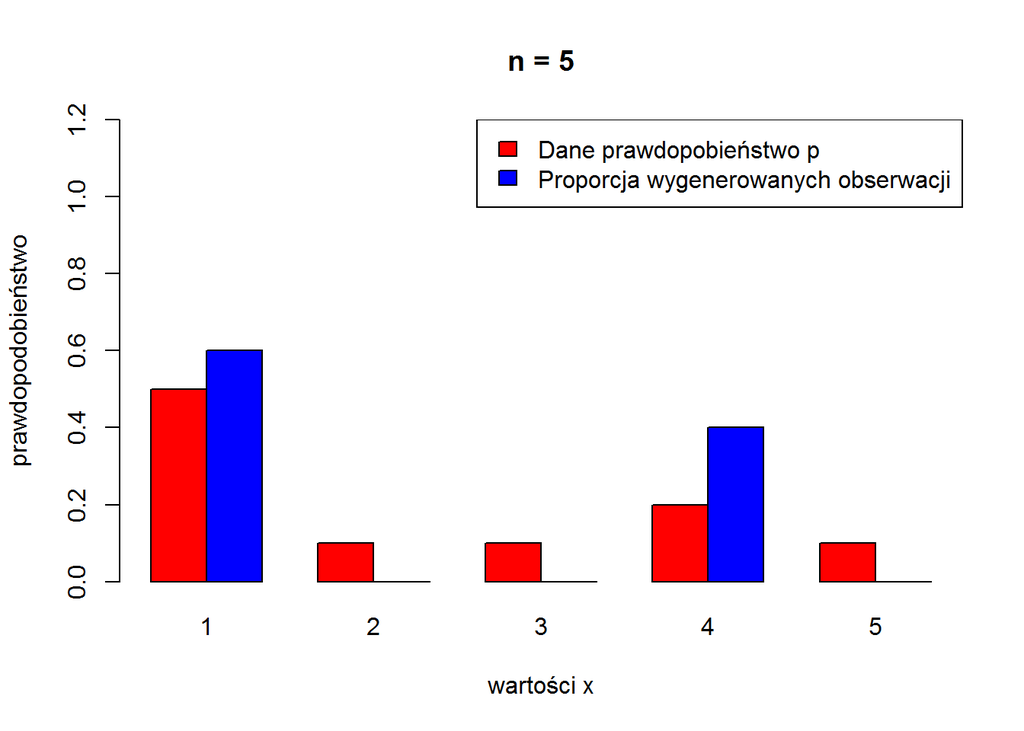

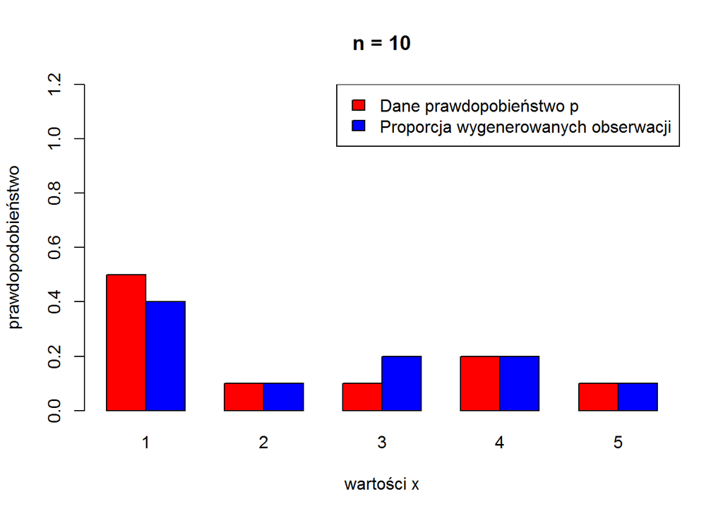

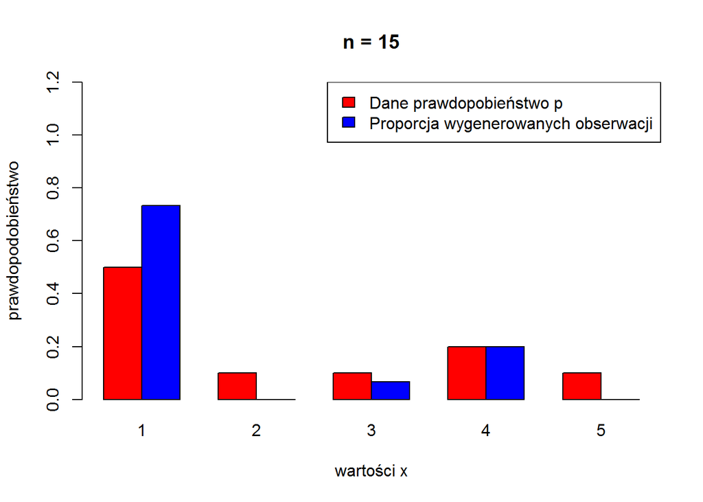

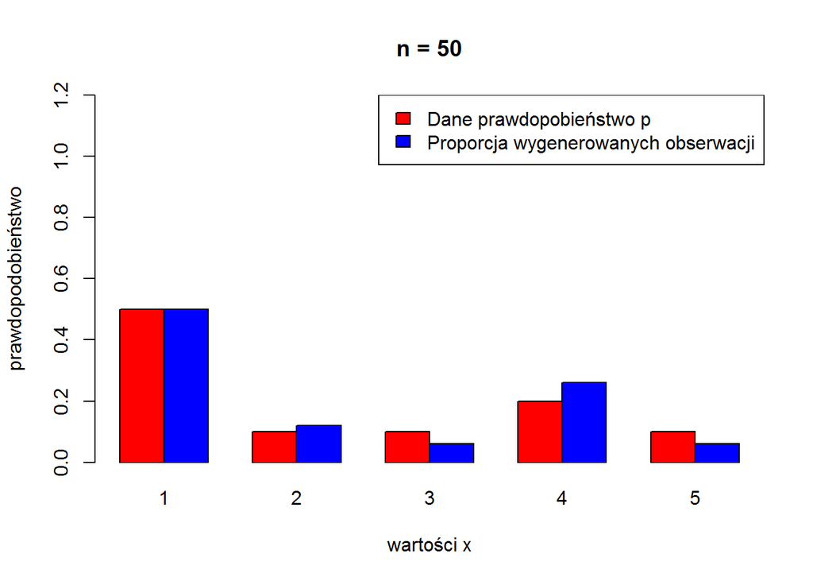

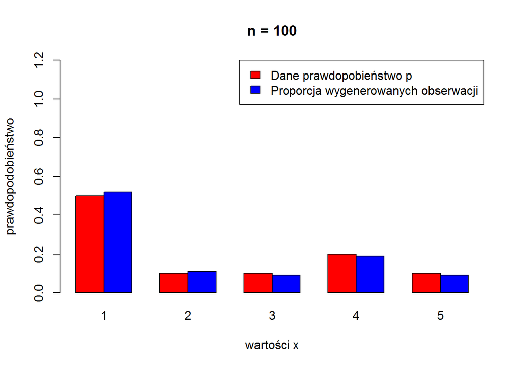

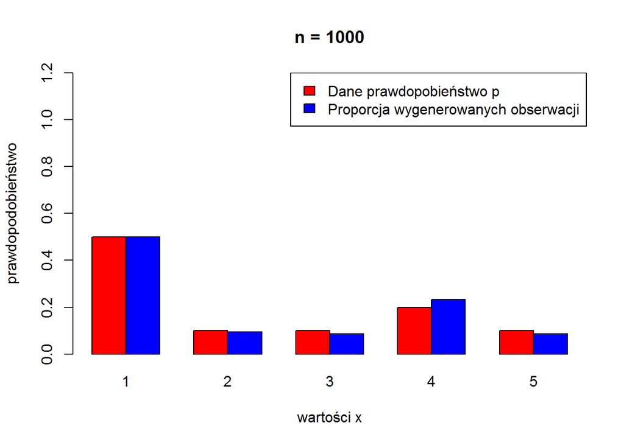

### Test 2

```r
x <- c(1,2,3,4,5,6,7,8)
p <- c(0.1, 0.3, 0.1, 0.1, 0.2, 0.1, 0.05, 0.05)
```

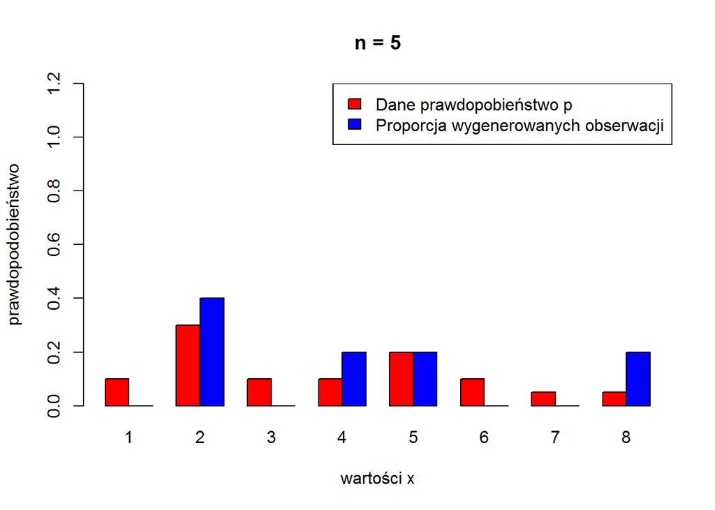

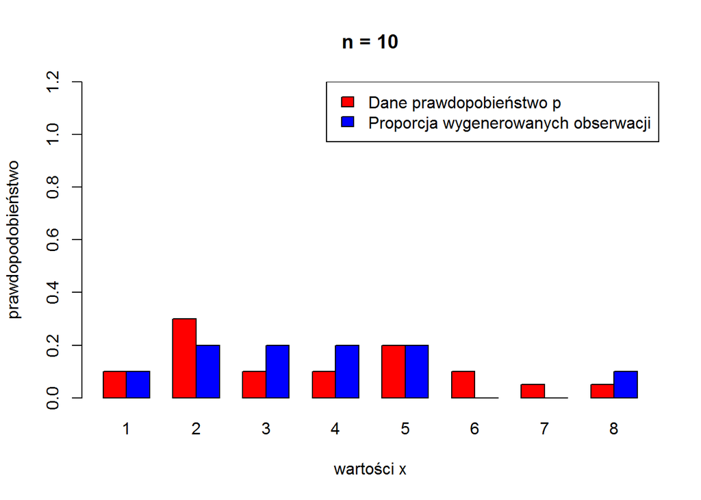

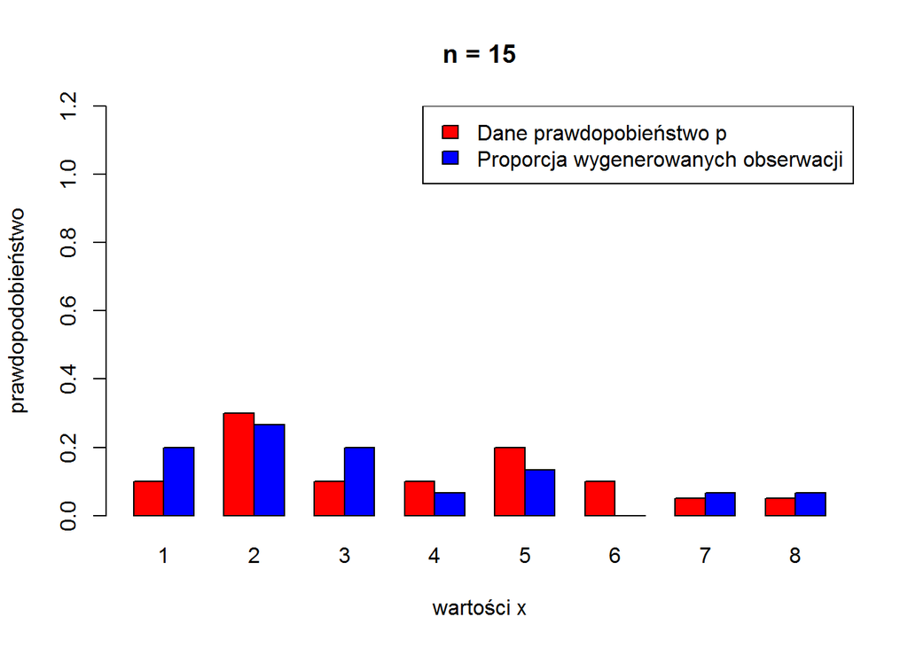

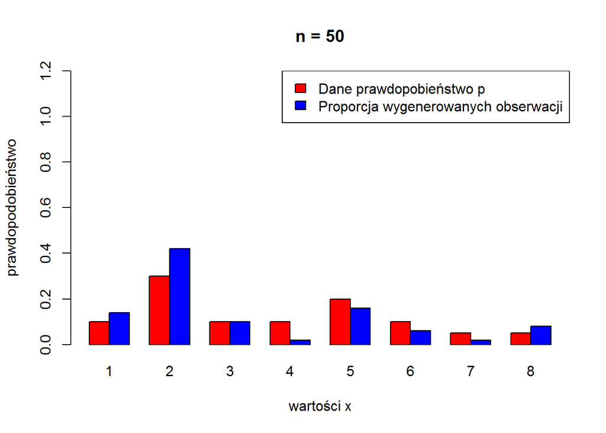

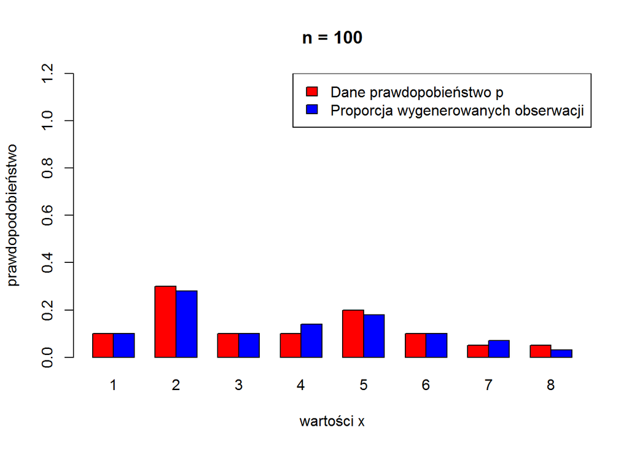

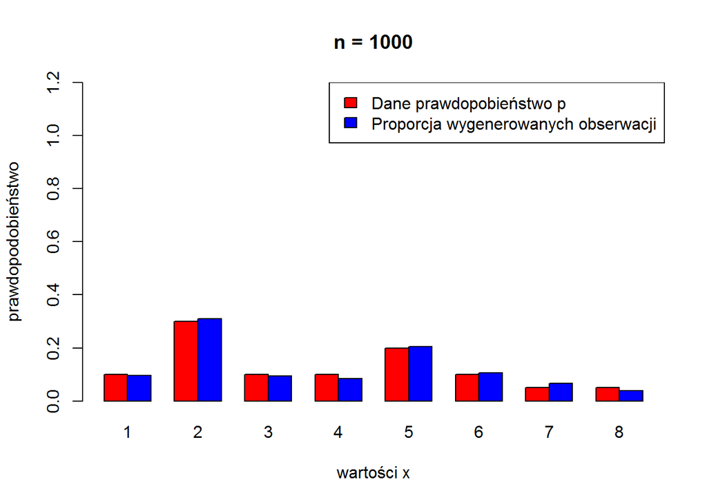

Dochodzimy do wniosku, że wraz ze wzrostem liczby elementów w wygenerowanej próbce, proporcje wartości są bliższe danym prawdopodobieństwom dla każdego rodzaju elementu.

# Zadanie 4

## Dyskusja

W zadaniu czwartym należało napisać dwie funkcje. Pierwsza z nich, `lead`, ,,usuwa’’ `n` początkowych obserwacji z danego wektora `x` i dodaje $n$ braków na koniec wektora `x`. Rozwiązanie jest następujące. Wystarczy stworzyć dodatkowy wektor, który pierwotnie wypełniony jest wartościami `NA`, a następnie przypisać `length(x) - n` końcowych wartości z wektora `x` na początek nowego wektora.

Implementacja drugiej funkcji jest analogiczna do rozwiązania przedstawionego powyżej

## Testy

### Test 1

```r
lead(c(1,2,3,4,5), 3)
```

```
## [1]  4  5 NA NA NA
```

### Test 2

```r
lead(c(1,2,3,4,5), 5)
```

```
## [1] NA NA NA NA NA
```

### Test 3

```r
lead(c(1,2,3,4,8,2,3,4), 3)
```

```
## [1]  4  8  2  3  4 NA NA NA
```

### Test 4

```r
lag(c(1,2,5,2,3,45,3), 2)
```

```
## [1] NA NA  1  2  5  2  3
```

### Test 5

```r
lag(c(1,5,3,3,3,5,2,4), 1)
```

```
## [1] NA  1  5  3  3  3  5  2
```

### Test 6

```r
lag(c(1,2,6,3,333,5,2,1,-2), 6)
```

```
## [1] NA NA NA NA NA NA  1  2  6
```

# Zadanie 5

## Dyskusja

Zadanie piąte polegało na wyznaczeniu wartości dystrybuanty empirycznej dla `x` we wszystkich punktach z wektora `y`.

### Rozwiązanie pierwsze

Pierwsze rozwiązanie polega na naiwnym obliczaniu dla każdego punktu z wektora `y`, ile jest wartości w wektorze `x` mniejszych bądź równych od aktualnie analizowanej wartości. Złożoność takiego rozwiązania jest względnie duża, mianowicie wynosi ona $O\,(n \cdot m)$ (gdzie $n = length(x)$, $m = length(y)$), gdyż dla każdego elementu z wektora `y` musimy przejść przez wszystkie elementu wektora `x`.

### Rozwiązanie drugie

Na początku obliczamy liczność każdej wartości występującej w wektorze `x` przy pomocy następującego polecenia:

```
rle(sort(x))
```

(Możnaby było tego dokonać również za pomocą funkcji `table`).

Dla każdej wartości wektora `y` znajdujemy, ile unikalnych liczb jest mniejszych bądź równych tej wartości:

```
ind <- findInterval(y, c(-Inf, unique(x)))
```

Dopisujemy ,,sztuczną’’ wartość `-Inf`, aby otrzymać zawsze otrzymać dodatni indeks przedziału. Wobec tego, otrzymamy w wyniku powyższej operacji zawsze wartości o $1$ większe, ale taki właśnie wynik będzie dla nas użyteczny w kolejnym kroku (przy odwoływaniu się do konkretnych miejsc innej tablicy).

W następnym kroku, obliczamy ile jest w wektorze `x` łącznie liczb mniejszych bądź równych danej wartości z `y` (tzn. uwzględniamy również powtórzenia). Możemy tego dokonać w następujący sposób. Obliczamy częściowe sumy (`cumsum`) dla wektora `rle(sort(x))$lengths` (i dopisujemy na początek 0, abyśmy nie musieli oddzielnie rozpatrywać przypadku, w którym nie ma żadnej liczby mniejszej bądź równej danej liczbie z wektora `y`). Naszym ostatecznym wynikiem jest wartość znajdująca się pod indeksem `ind` w wektorze sum częściowych.

Zauważmy, że tak zaimplementowane rozwiązanie jest wydajniejsze od rozwiązania pierwszego. Jako że liczby oznaczające początki/końce przedziałów są posortowane, to dla każdego elementu z wektora `y` możemy znaleźć odpowiadający mu przedział w czasie logarytmicznym względem liczby unikalnych elementów w wektorze `x`. Złożoność obliczeniowa przedstawionego powyżej rozwiązania wynosi $O(log(length(unique(x))) \cdot length(y) + length(x) \cdot log(length(x)))$, gdyż numery przedziałów są znajdowane za pomocą przeszukiwania binarnego.

W szczególności, powinniśmy zauważyć znaczące przyspieszenie w momencie, gdy powtarza się dużo wartości w wektorze `x`.

## Testy

### Przykładowe wywołanie

```r
x <- c(1,1,6,2,3,3,3,5,5)
y <- seq(1, 6, 0.1)
roz2 <- Fn(x, y)
roz1 <- Fn_roz1(x, y)
roz2
```

```
##  [1] 0.2222222 0.2222222 0.2222222 0.2222222 0.2222222 0.2222222 0.2222222
##  [8] 0.2222222 0.2222222 0.2222222 0.3333333 0.3333333 0.3333333 0.3333333
## [15] 0.3333333 0.3333333 0.3333333 0.3333333 0.3333333 0.3333333 0.6666667
## [22] 0.6666667 0.6666667 0.6666667 0.6666667 0.6666667 0.6666667 0.6666667
## [29] 0.6666667 0.6666667 0.6666667 0.6666667 0.6666667 0.6666667 0.6666667
## [36] 0.6666667 0.6666667 0.6666667 0.6666667 0.6666667 0.8888889 0.8888889
## [43] 0.8888889 0.8888889 0.8888889 0.8888889 0.8888889 0.8888889 0.8888889
## [50] 0.8888889 1.0000000
```

```r
all(roz1 == roz2)
```

```
## [1] TRUE
```

### Przykładowy wykres

```r
set.seed(53)
y <- seq(-10, 10, 0.2)
x <- rnorm(10, 0, 4)
```

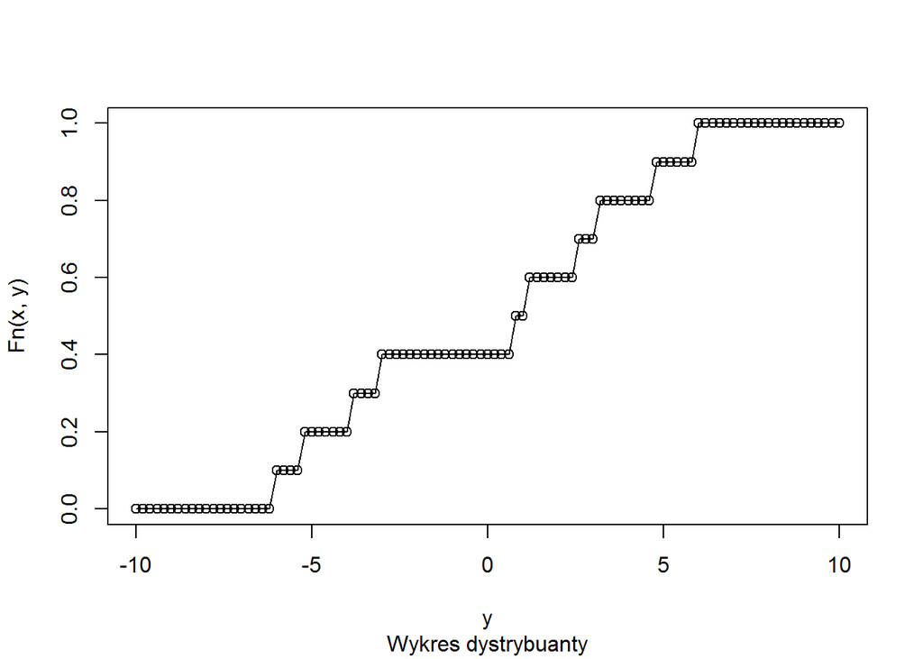